# IRB Application Preparation and Submission

Course submission package and IRB applicability statement

Author

Yushan Huang, Gabriela Raygoza Quintero, Alondra Rodriguez, and Simran Kaur

Published

October 16, 2026

> **Submission status:** Course preparation package. No Cayuse IRB protocol has been filed or approved. This report does not represent an IRB determination or permission to recruit participants.

## 1. Assignment Overview

This package documents our preparation for **GP08-2: IRB Application Preparation and Submission**. It includes evidence of human-subjects training, a published Qualtrics questionnaire created for a course-based survey-design exercise, the informed-consent cover page, and the related Construct and Measurement Table. The instructor has not yet provided comments on the questionnaire or table.

## 2. Current CEP Project and IRB Applicability

Our CEP project direction was recently revised in consultation with Dr. Lin. The current work is an **AI-assisted meta-analysis using CALIPER**, focused on personalization in digital marketing communication. It is designed to use existing published studies and previously deposited human-coded secondary data, rather than recruiting new survey participants. Dr. Lin indicated that no new survey or IRB application is planned for this revised project.

The Qualtrics survey linked below reflects an **earlier SGV/TBFI consumer-survey design exercise**. It is included here as evidence of questionnaire design and informed-consent preparation; it is **not the data-collection instrument for the current CALIPER meta-analysis**. Publishing a link does not authorize recruitment. We are not representing this survey as IRB-approved and are not using it to recruit research participants.

**Cayuse status:** No online study draft or Cayuse draft URL is available for this project. Whether the course instructor will accept this explanation in place of a draft protocol and application document remains **pending instructor confirmation**. Any official human-subjects/IRB determination is made by the institution’s authorized office, not by the student team.

## 3. IRB Package Checklist

[output not shown]

## 4. CITI Training Evidence

> **Yushan Huang** completed the **Human Research : College of Business Administration - Basic Course** under California State Polytechnic University, Pomona requirements on **October 9, 2026**. The certificate lists an expiration date of **October 9, 2031**.

> Open the CITI completion certificate (PDF)

> **Simran Kaur** completed the **Human Research, College of Business Administration, Basic Course** under California State Polytechnic University, Pomona requirements on **October 8, 2026**. The certificate lists an expiration date of **October 8, 2031**.

> > [CITI completion certificate](https://www.citiprogram.org/verify/?wa48794b5-4234-4f98-b7d0-d7b6e6992b3b-80159492)

> [Open the CITI completion certificate](https://www.citiprogram.org/verify/?wc6928900-a785-4482-9a31-fc9489026dab-80299254)

> Open the CITI completion certificate

## 5. Qualtrics Questionnaire and Measurement Preparation

**Questionnaire:** [Open the published Qualtrics survey](https://cpp.az1.qualtrics.com/jfe/form/SV_2ujgUci31v9QF4W).

The survey cover page describes a San Gabriel Valley consumer-perception questionnaire, estimates a **7–9 minute** completion time, and includes a voluntary-participation statement and an affirmative/negative consent choice. The survey was created for questionnaire-design practice and is separate from the current CALIPER research plan.

**Construct and Measurement Table:** [Open Group 8’s GP05 C&M Table](https://docs.google.com/document/d/1ZI18GTDaXHCRTz3x4cXcZvnghRol7qQ8/edit?usp=sharing). The earlier GP05 source file is also included in the submission bundle. It describes the earlier project scope and has **not** been updated to represent the revised CALIPER objectives.

**Faculty feedback:** No feedback had been received as of this report’s preparation. Revisions will be made when the instructor provides comments.

## 6. Informed Consent Cover Page

The screenshots below show the current cover page, including the study purpose, estimated time, voluntary participation, privacy and risk/benefit language, contact details, and Yes/No consent choices. The screenshots are evidence of the course exercise, not proof of IRB approval.

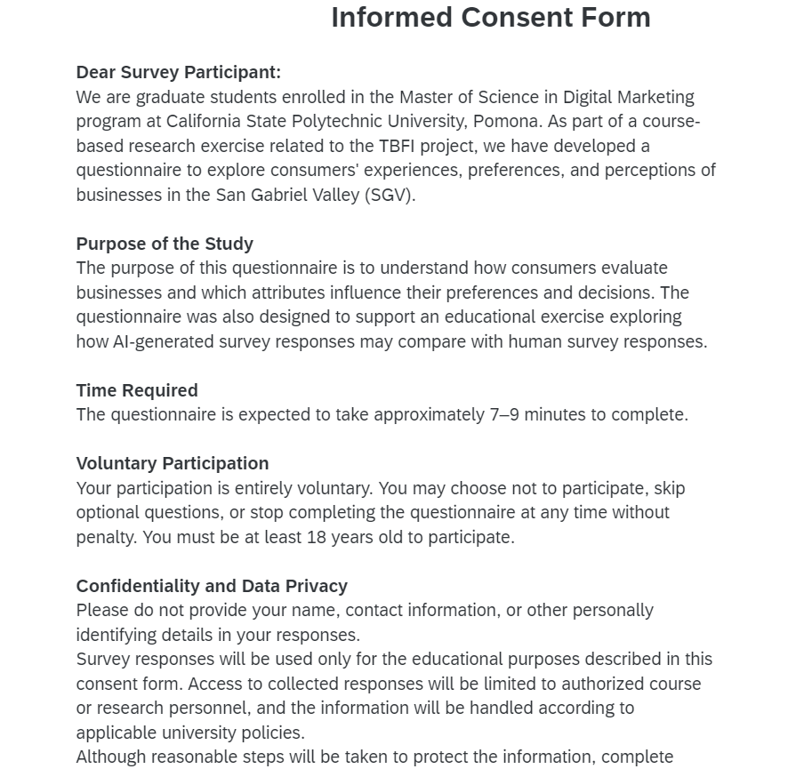

Qualtrics informed consent — upper section

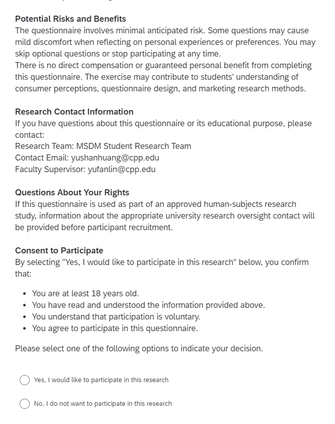

Qualtrics informed consent — lower section and consent choices

**Pre-recruitment check:** If this survey were ever used for actual human-subjects research, the team would first need to verify its consent language, privacy practices, appropriate rights contact, eligibility and refusal-termination logic, and any required institutional review/approval. The current exercise does not authorize recruitment.

**Institutional resource:** [CPP IRB Protocol Information](https://www.cpp.edu/research/research-compliance/irb/protocol.shtml).

**IRB report pages link:** https://gabrielarq1.github.io/CEP--Group-8/CEP08/GP08_IRB_Application.html